# Report 02: Core Presentation-State Model — Static Decoupling & Simplex Geometry

Testing pointwise protein readout vs. within-donor 9-mer simplex representations and Proposition 1 rank-66 proof

Amir Asiaee, Nebojša Jojić, Elizabeth J. Phillips, and Simon A. Mallal

November 22, 2026

Back to Master Index | Previous: Report 01 | Next: Report 03 — Cross-Lineage & Six-Omic Cohorts

# 1 Pointwise Proteome–Peptidome Decoupling and Replicate Noise Nulls

### 1.0.1 Rationale

Under a naive concentration-readout model ($y_{sp} \approx C \cdot x_{sg(p)}$), shifting parent-protein abundance should drive proportional shifts in derived HLA-I peptides, and sibling peptides from the same gene should move together. I evaluate the pointwise regression $\Delta\log_2 \mathrm{Pep}_p = \alpha + \beta_{\mathrm{Prot}}\,\Delta\log_2 \mathrm{Prot}_{g(p)} + \varepsilon_p$ across all eight proteome-matched contrasts (five `Bathini`/`Chong` label-free/DIA backgrounds, `Stopfer 2022` `SKMEL5` TMT MEKi, and `Bernhardt 2025` `Ma-Mel-63a` pulsed-SILAC IFN-$\gamma$ at 24 h and 72 h). I then test two diagnostics: (1) errors-in-variables disattenuated $R^2$ using empirical within-condition replicate reliabilities $\hat{\rho}_{\mathrm{Pep}}$ and $\hat{\rho}_{\mathrm{Prot}}$; and (2) 500-draw Monte Carlo nulls simulating sibling noise $\mathcal{N}(0, s_{\Delta,i}^2)$ under identical true gene fold changes.

```python
elast_t = pd.read_csv(res_path("exp1_concentration_decoupling", "perturbation_elasticity_summary.tsv"), sep="\t")
f7a_t = pd.read_csv(res_path("exp7_distributional_sensing", "exp7a_followup_elasticity_and_ub.tsv"), sep="\t")
disatt_t = pd.read_csv(res_path("falsification_controls", "disattenuation_and_sibling_null.tsv"), sep="\t")

elast_view = elast_t.merge(
    disatt_t[["background", "dPep_reliability_ceiling", "dProt_reliability", "r2_fully_disattenuated", "multiplicity_noise_null_gt2x", "multiplicity_noise_null_p95", "fold_over_noise_null"]],
    on="background",
    how="left"
)[["background", "perturbation", "n_surviving_peptides", "elasticity_beta", "r_squared", "dPep_reliability_ceiling", "dProt_reliability", "r2_fully_disattenuated", "frac_genes_diverging_gt_2fold", "multiplicity_noise_null_gt2x", "fold_over_noise_null"]]

f7a_view = f7a_t[["cohort", "n_peptides", "n_genes", "slope_dPep_dProt", "r_squared", "disattenuated_r_squared", "rna_r_squared", "frac_multi_genes_gt_2fold"]]
```

```r
show_tbl(py$elast_view, digits = 3, caption = "Table 2.1: Proteome-peptidome elasticity, errors-in-variables disattenuated R2, and multiplicity-matched sibling nulls (label-free/DIA cohorts).")
```

Table 2.1: Proteome-peptidome elasticity, errors-in-variables disattenuated R2, and multiplicity-matched sibling nulls (label-free/DIA cohorts).

|  | background | perturbation | n_surviving_peptides | elasticity_beta | r_squared | dPep_reliability_ceiling | dProt_reliability | r2_fully_disattenuated | frac_genes_diverging_gt_2fold | multiplicity_noise_null_gt2x | fold_over_noise_null |
| --- | --- | --- | --- | --- | --- | --- | --- | --- | --- | --- | --- |
| 0 | ITO57T | IFNG | 1281 | 0.557 | 0.025 | 0.844 | 0.952 | 0.032 | 0.518 | 0.186 | 2.784 |
| 1 | ITO58M | IFNG | 1339 | 1.058 | 0.156 | 0.915 | 0.959 | 0.178 | 0.458 | 0.156 | 2.944 |
| 2 | ITO66T | IFNG | 1612 | 0.746 | 0.096 | 0.928 | 0.943 | 0.110 | 0.267 | 0.109 | 2.454 |
| 3 | UWB1.289 | IFNG | 1566 | 0.361 | 0.011 | 0.987 | 0.906 | 0.012 | 0.608 | 0.046 | 13.190 |
| 4 | A375 | TGFB | 1580 | 0.508 | 0.057 | 0.743 | 0.826 | 0.094 | 0.181 | 0.141 | 1.287 |

```r
show_tbl(py$f7a_view, digits = 3, caption = "Table 2.2: Follow-up proteome/RNA elasticity and sibling divergence in SKMEL5 MEKi (TMT) and Ma-Mel-63a IFNg (pSILAC).")
```

Table 2.2: Follow-up proteome/RNA elasticity and sibling divergence in SKMEL5 MEKi (TMT) and Ma-Mel-63a IFNg (pSILAC).

| cohort | n_peptides | n_genes | slope_dPep_dProt | r_squared | disattenuated_r_squared | rna_r_squared | frac_multi_genes_gt_2fold |
| --- | --- | --- | --- | --- | --- | --- | --- |
| Stopfer2022_SKMEL5_MEKi_100nM_72h | 1487 | 980 | 0.161 | 0.031 | 0.038 | 0.062 | 0.037 |
| Bernhardt2025_MaMel63a_IFNg_24h | 2054 | 1223 | 0.210 | 0.004 | NaN | NaN | 0.604 |
| Bernhardt2025_MaMel63a_IFNg_72h | 1917 | 1193 | 0.370 | 0.017 | NaN | NaN | 0.667 |

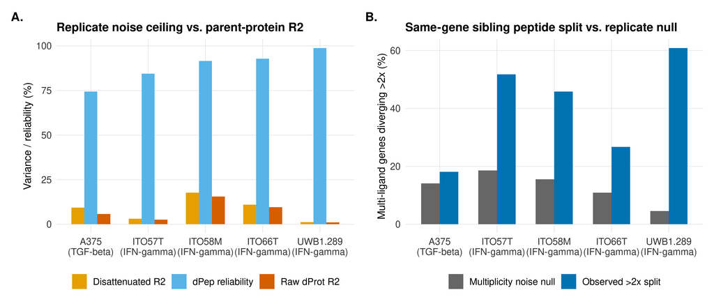

```r
d6 <- py$disatt_t |>
  mutate(Label = paste0(background, "\n(", ifelse(perturbation == "IFNG", "IFN-gamma", "TGF-beta"), ")"))

p_dis <- d6 |>
  select(Label, r2_raw, r2_fully_disattenuated, dPep_reliability_ceiling) |>
  pivot_longer(-Label, names_to = "Metric", values_to = "Val") |>
  mutate(Metric = recode(Metric, r2_raw = "Raw dProt R2", r2_fully_disattenuated = "Disattenuated R2", dPep_reliability_ceiling = "dPep reliability")) |>
  ggplot(aes(x = Label, y = 100 * Val, fill = Metric)) +
  geom_col(position = "dodge", width = 0.68) +
  scale_fill_manual(values = c("Raw dProt R2" = ORANGE, "Disattenuated R2" = GOLD, "dPep reliability" = LBLUE)) +
  labs(x = NULL, y = "Variance / reliability (%)", fill = NULL, title = "Replicate noise ceiling vs. parent-protein R2")

p_sib <- d6 |>
  select(Label, obs_frac_gt2x_split, multiplicity_noise_null_gt2x) |>
  pivot_longer(-Label, names_to = "Source", values_to = "Frac") |>
  mutate(Source = recode(Source, obs_frac_gt2x_split = "Observed >2x split", multiplicity_noise_null_gt2x = "Multiplicity noise null")) |>
  ggplot(aes(x = Label, y = 100 * Frac, fill = Source)) +
  geom_col(position = "dodge", width = 0.65) +
  scale_fill_manual(values = c("Observed >2x split" = BLUE, "Multiplicity noise null" = GRAY)) +
  labs(x = NULL, y = "Multi-ligand genes diverging >2x (%)", fill = NULL, title = "Same-gene sibling peptide split vs. replicate null")

tagged(p_dis + p_sib)
```

**What do we see?**

Across all eight proteome-matched backgrounds (Tables 2.1–2.2 and Figure 2.1), steady-state or perturbed parent-protein fold-change leaves over `82%` of HLA-I peptide variance unexplained:

1. **Weak pointwise tracking before and after error disattenuation:** Raw OLS $R^2$ ranges from `1.1%` in `UWB1.289` (`n = 1,566`, `beta = 0.361`) and `2.5%` in `ITO57T` (`n = 1,281`, `beta = 0.557`) to `9.6%` in `ITO66T` (`n = 1,612`, `beta = 0.746`) and `15.6%` in `ITO58M` (`n = 1,339`, `beta = 1.058`), while `A375` TGF-$\beta$ reaches `5.7%` (`n = 1,580`). Follow-up TMT (`Stopfer 2022 SKMEL5`, `n = 1,487`, `R^2 = 3.1%` proteome / `6.2%` RNA-seq) and pSILAC (`Bernhardt Ma-Mel-63a` IFN-$\gamma$, `0.4%` at 24 h / `1.7%` at 72 h) show even weaker pointwise coupling. Crucially, `dPep` replicate reliability ceilings stand high at `74.3%–98.7%` (`dProt` reliability `82.6%–95.9%`), so full errors-in-variables disattenuation raises $R^2_{\mathrm{disatt}}$ only slightly to `1.2%–17.8%` (`3.8%` in `SKMEL5`). Measurement error therefore cannot rescue the concentration-readout model.
2. **Pervasive same-gene sibling splitting:** Across the four replicate-level IFN-$\gamma$ backgrounds, `26.7%` (`ITO66T`), `45.8%` (`ITO58M`), `51.8%` (`ITO57T`), and `60.8%` (`UWB1.289`) of multi-ligand parent proteins display $>2$-fold divergence between co-derived peptides, exceeding multiplicity-matched Gaussian noise nulls (`4.6%–18.6%`) by **`2.45x` to `13.19x`**. `Ma-Mel-63a` pulsed-SILAC shows `60.4%` (24 h) and `66.7%` (72 h) multi-ligand splitting, whereas non-inflammatory `A375 TGF-beta` (`18.1%`, `1.29x` null) and `SKMEL5 MEKi` (`3.7%`) exhibit minimal sibling divergence.

# 2 Why Unpaired Single Biopsies Fail: Donor Polymorphism and Stromal Collinearity

### 2.0.1 Rationale

Even if individual peptides decouple from parent proteins, could a static cross-sectional peptide profile still separate tumor states or perturbations across donors? I evaluate both unpaired and within-donor paired classification on same-era 2018 `Newey` colorectal organoids (`n=34` observations comparing IFN-$\gamma$ vs. trametinib), and audit cross-patient clustering (`ARI` against DNA methylation and RNA), the 6-rung representation ladder, and `Hallmark Angiogenesis` microvascular/HLA-I collinearity across `N=28` primary `Velz` medulloblastomas.

```python
bench_t = pd.read_csv(res_path("exp1_concentration_decoupling", "decoding_benchmark_synthesis.tsv"), sep="\t")
velz_ari_all = pd.read_csv(res_path("exp8_immunity_bridge", "velz_ari_all_pairs.csv"))
velz_col = pd.read_csv(res_path("exp1_concentration_decoupling", "velz_angiogenesis_collinearity.tsv"), sep="\t")
velz_lad = pd.read_csv(res_path("exp7_distributional_sensing", "exp7b_velz_representation_ladder.tsv"), sep="\t")
newey_lad = pd.read_csv(res_path("exp8_immunity_bridge", "tableS12_newey_unpaired_vs_paired_all11.csv"))
velz_scores = pd.read_csv(res_path("exp1_concentration_decoupling", "velz_microenvironment_patient_scores.tsv"), sep="\t")
```

```r
show_tbl(py$bench_t, digits = 4, caption = "Table 2.3: Unpaired single-sample vs. paired within-organoid decoding and Velz k=4 unsupervised ARI.")
```

Table 2.3: Unpaired single-sample vs. paired within-organoid decoding and Velz k=4 unsupervised ARI.

| task | representation | primary_metric_name | primary_metric | reference_value | secondary_metric_name | secondary_metric |
| --- | --- | --- | --- | --- | --- | --- |
| Newey CRC PDO single-sample classification (IFNg vs MEKi, 4 PDOs) | Coarse P4-P7 chemistry (96 features, rank 66) | Balanced accuracy | 0.5000 | 0.5 | Within-PDO AUROC | 1.0000 |
| Newey CRC PDO paired same-background ordering (4 PDOs) | Coarse P4-P7 chemistry (96 features) | Pair concordance | 0.9844 | 0.5 | AA composition baseline concordance | 1.0000 |
| Velz medulloblastoma k=4 partition agreement (RNA vs coarse96, N=28) | RNA vs coarse96 | Adjusted Rand Index (ARI) | 0.0301 | 0.0 | BH q-value | 0.6255 |
| Velz medulloblastoma k=4 partition agreement (RNA vs aa20, N=28) | RNA vs aa20 | Adjusted Rand Index (ARI) | 0.0677 | 0.0 | BH q-value | 0.5115 |
| Velz medulloblastoma k=4 partition agreement (RNA vs anchor16, N=28) | RNA vs anchor16 | Adjusted Rand Index (ARI) | -0.0679 | 0.0 | BH q-value | 1.0000 |
| Velz medulloblastoma k=4 partition agreement (RNA vs peptide, N=28) | RNA vs peptide | Adjusted Rand Index (ARI) | 0.0272 | 0.0 | BH q-value | 0.6255 |
| Velz medulloblastoma k=4 partition agreement (RNA vs depth, N=28) | RNA vs depth | Adjusted Rand Index (ARI) | -0.0761 | 0.0 | BH q-value | 1.0000 |
| Velz medulloblastoma k=4 partition agreement (RNA vs hla_center, N=28) | RNA vs hla_center | Adjusted Rand Index (ARI) | 0.0416 | 0.0 | BH q-value | 0.6042 |
| Velz medulloblastoma k=4 partition agreement (RNA vs methylation, N=28) | RNA vs methylation | Adjusted Rand Index (ARI) | 0.6538 | 0.0 | BH q-value | 0.0130 |
| Velz medulloblastoma k=4 partition agreement (coarse96 vs methylation, N=28) | coarse96 vs methylation | Adjusted Rand Index (ARI) | 0.1052 | 0.0 | BH q-value | 0.3442 |
| Velz medulloblastoma k=4 partition agreement (aa20 vs methylation, N=28) | aa20 vs methylation | Adjusted Rand Index (ARI) | 0.0340 | 0.0 | BH q-value | 0.6255 |
| Velz medulloblastoma k=4 partition agreement (anchor16 vs methylation, N=28) | anchor16 vs methylation | Adjusted Rand Index (ARI) | -0.0508 | 0.0 | BH q-value | 1.0000 |
| Velz medulloblastoma k=4 partition agreement (peptide vs methylation, N=28) | peptide vs methylation | Adjusted Rand Index (ARI) | -0.0180 | 0.0 | BH q-value | 1.0000 |
| Velz medulloblastoma k=4 partition agreement (depth vs methylation, N=28) | depth vs methylation | Adjusted Rand Index (ARI) | -0.0640 | 0.0 | BH q-value | 1.0000 |
| Velz medulloblastoma k=4 partition agreement (hla_center vs methylation, N=28) | hla_center vs methylation | Adjusted Rand Index (ARI) | 0.0508 | 0.0 | BH q-value | 0.5437 |

```r
show_tbl(py$velz_ari_all, digits = 4, caption = "Table 2.3b: Complete Velz N=28 k=4 partition ARI matrix comparing HLA-I representations against both RNA-seq and 850k DNA methylation.")
```

Table 2.3b: Complete Velz N=28 k=4 partition ARI matrix comparing HLA-I representations against both RNA-seq and 850k DNA methylation.

| k | first | second | metric | score | p | q_bh |
| --- | --- | --- | --- | --- | --- | --- |
| 4 | RNA | coarse96 | ARI | 0.0301 | 0.2887 | 0.6255 |
| 4 | RNA | aa20 | ARI | 0.0677 | 0.1279 | 0.5115 |
| 4 | RNA | anchor16 | ARI | -0.0679 | 0.9720 | 1.0000 |
| 4 | RNA | peptide | ARI | 0.0272 | 0.2627 | 0.6255 |
| 4 | RNA | depth | ARI | -0.0761 | 0.9950 | 1.0000 |
| 4 | RNA | hla_center | ARI | 0.0416 | 0.2188 | 0.6042 |
| 4 | RNA | methylation | ARI | 0.6538 | 0.0010 | 0.0130 |
| 4 | coarse96 | methylation | ARI | 0.1052 | 0.0529 | 0.3442 |
| 4 | aa20 | methylation | ARI | 0.0340 | 0.2737 | 0.6255 |
| 4 | anchor16 | methylation | ARI | -0.0508 | 0.9331 | 1.0000 |
| 4 | peptide | methylation | ARI | -0.0180 | 0.9081 | 1.0000 |
| 4 | depth | methylation | ARI | -0.0640 | 0.9820 | 1.0000 |
| 4 | hla_center | methylation | ARI | 0.0508 | 0.1528 | 0.5437 |

```r
show_tbl(py$velz_col[, c("covariate", "pearson_r_target", "pearson_p_target", "perm_p_target", "within_subgroup_partial_r_target")], digits = 4, caption = "Table 2.4: Velz N=28 Angiogenesis mRNA collinearity with HLA-I/B2M and stromal/immune transcripts.")
```

Table 2.4: Velz N=28 Angiogenesis mRNA collinearity with HLA-I/B2M and stromal/immune transcripts.

| covariate | pearson_r_target | pearson_p_target | perm_p_target | within_subgroup_partial_r_target |
| --- | --- | --- | --- | --- |
| hla_i_b2m_mrna | 0.7875 | 0.0000 | 0.0001 | 0.7928 |
| appm_mrna | 0.7477 | 0.0000 | 0.0001 | 0.7572 |
| endothelial_mrna | 0.6847 | 0.0001 | 0.0002 | 0.7199 |
| myeloid_mrna | 0.6880 | 0.0001 | 0.0001 | 0.7159 |
| ecm_stromal_mrna | 0.4849 | 0.0089 | 0.0093 | 0.5104 |
| tcell_mrna | 0.5093 | 0.0056 | 0.0045 | 0.5174 |

```r
show_tbl(py$velz_lad, digits = 3, caption = "Table 2.5: Velz N=28 6-rung single-biopsy representation ladder relative to molecular subgroup means.")
```

Table 2.5: Velz N=28 6-rung single-biopsy representation ladder relative to molecular subgroup means.

| cohort_task | representation | prolif_rel_mse_vs_subgroup | ifng_rel_mse_vs_subgroup | subgroup_k4_bal_acc |
| --- | --- | --- | --- | --- |
| Velz_N28_CrossPatient_BaselineFree | R0_Quantity_Depth | 1.000 | 1.000 | 0.323 |
| Velz_N28_CrossPatient_BaselineFree | R1_Coarse96 | 0.994 | 0.899 | 0.299 |
| Velz_N28_CrossPatient_BaselineFree | R2a_AA20 | 1.002 | 1.010 | 0.300 |
| Velz_N28_CrossPatient_BaselineFree | R2_PosAA180 | 1.008 | 1.021 | 0.243 |
| Velz_N28_CrossPatient_BaselineFree | R4_Peptide_Identity | 0.991 | 1.152 | 0.300 |
| Velz_N28_CrossPatient_BaselineFree | R5_SourceGene_Oracle | 0.994 | 1.103 | 0.398 |
| Velz_N28_CrossPatient_BaselineFree | R3_Nonlinear_RBF_PosAA180 | 0.998 | 1.005 | 0.212 |

```r
show_tbl(py$newey_lad, digits = 3, caption = "Table 2.6: Complete 11-representation Newey 2018 colorectal PDO single-sample vs. paired within-organoid ladder.")
```

Table 2.6: Complete 11-representation Newey 2018 colorectal PDO single-sample vs. paired within-organoid ladder.

| cohort_task | representation | single_sample_loo_bal_acc | single_sample_loo_auroc | paired_shift_loo_concordance | paired_shift_worst_org |
| --- | --- | --- | --- | --- | --- |
| Newey_CRC_PDO_IFNg_vs_MEKi | R0_Quantity_Length | 0.556 | 0.726 | 0.938 | 0.750 |
| Newey_CRC_PDO_IFNg_vs_MEKi | R1_Coarse96 | 0.594 | 0.729 | 0.984 | 0.938 |
| Newey_CRC_PDO_IFNg_vs_MEKi | R1b_Coarse96_Presence | 0.472 | 0.566 | 0.979 | 0.917 |
| Newey_CRC_PDO_IFNg_vs_MEKi | R1c_Coarse96_Sub500 | 0.403 | 0.410 | 0.667 | 0.375 |
| Newey_CRC_PDO_IFNg_vs_MEKi | R2a_AA20 | 0.594 | 0.868 | 1.000 | 1.000 |
| Newey_CRC_PDO_IFNg_vs_MEKi | R2b_Pos80_Internal | 0.719 | 0.726 | 0.854 | 0.667 |
| Newey_CRC_PDO_IFNg_vs_MEKi | R2c_Anchor40 | 0.628 | 0.656 | 0.896 | 0.750 |
| Newey_CRC_PDO_IFNg_vs_MEKi | R2_PosAA180 | 0.594 | 0.788 | 0.938 | 0.750 |
| Newey_CRC_PDO_IFNg_vs_MEKi | R4_Peptide_Identity | 0.691 | 0.726 | 0.909 | 0.688 |
| Newey_CRC_PDO_IFNg_vs_MEKi | R5_SourceGene_Oracle | 0.688 | 0.771 | 0.750 | 0.500 |
| Newey_CRC_PDO_IFNg_vs_MEKi | R3_Nonlinear_RBF_PosAA180 | 0.500 | 0.573 | 0.794 | 0.425 |

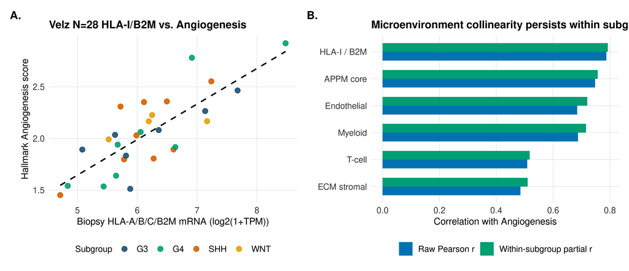

```r
vs <- py$velz_scores
p_v1 <- ggplot(vs, aes(x = hla_i_b2m_mrna, y = angiogenesis_target, color = molecular_subgroup)) +
  geom_point(size = 2.6, alpha = 0.9) +
  geom_smooth(method = "lm", se = FALSE, color = "#111111", linetype = "dashed", linewidth = 0.8, aes(group = 1)) +
  scale_color_manual(values = c(WNT = GOLD, SHH = ORANGE, G3 = NAVY, G4 = TEAL)) +
  labs(x = "Biopsy HLA-A/B/C/B2M mRNA (log2(1+TPM))", y = "Hallmark Angiogenesis score", color = "Subgroup", title = "Velz N=28 HLA-I/B2M vs. Angiogenesis")

p_v2 <- py$velz_col |>
  mutate(Cov = recode(covariate, hla_i_b2m_mrna = "HLA-I / B2M", appm_mrna = "APPM core", myeloid_mrna = "Myeloid", endothelial_mrna = "Endothelial", tcell_mrna = "T-cell", ecm_stromal_mrna = "ECM stromal")) |>
  pivot_longer(c(pearson_r_target, within_subgroup_partial_r_target), names_to = "Type", values_to = "r") |>
  mutate(Type = recode(Type, pearson_r_target = "Raw Pearson r", within_subgroup_partial_r_target = "Within-subgroup partial r")) |>
  ggplot(aes(x = reorder(Cov, r), y = r, fill = Type)) +
  geom_col(position = "dodge", width = 0.65) +
  coord_flip() +
  scale_fill_manual(values = c("Raw Pearson r" = BLUE, "Within-subgroup partial r" = TEAL)) +
  labs(x = NULL, y = "Correlation with Angiogenesis", fill = NULL, title = "Microenvironment collinearity persists within subgroup")

tagged(p_v1 + p_v2)
```

**What do we see?**

Unpaired cross-sectional profiles collapse across human donors because genetic HLA variation and stromal infiltration swamp intracellular state (Tables 2.3–2.6 and Figure 2.2):

- **Paired vs. unpaired decoding in `Newey` CRC organoids (`n = 34`):** Unpaired leave-one-organoid-out classification across same-era 2018 runs sits at exact chance (`0.500` balanced accuracy for fixed `Coarse96` and `0.403–0.719` across nested representation tiers; `R2_PosAA180 = 0.594`). Taking paired same-background differences restores pair ordering concordance to **`0.9844`** (`Coarse96`) and **`1.000`** (`AA20`; `0.938` `PosAA180`), with worst-organoid concordance jumping from near chance to `0.938` (`Coarse96`) and `1.000` (`AA20`).
- **Single-biopsy ceiling in `Velz N = 28` primary medulloblastomas:** While bulk RNA-seq and 850k DNA methylation agree on `k = 4` molecular subgroups (`ARI = 0.6538`, `BH q = 0.0130`), baseline-free HLA-I representations yield weak cluster agreement against both RNA-seq (`Coarse96 ARI = 0.0301`, range `-0.0761` to `0.0677`, `q >= 0.51`) and DNA methylation (`Coarse96 ARI = 0.1052`, `q = 0.3442`; range `-0.0640` to `0.1052`, Table 2.3b). Across the 6-rung single-biopsy ladder (Table 2.5), cross-patient `Proliferation` and `IFN-gamma` prediction stays at relative MSE `0.991–1.008` and `0.899–1.152` relative to subgroup means, with `k = 4` balanced accuracy capped at `0.212–0.398`. Moreover, `Hallmark Angiogenesis` tracks `HLA-I/B2M` mRNA ($r = 0.7875$, within-subgroup partial $r = 0.7928$), `APPM` core mRNA ($r = 0.7477$), myeloid transcripts ($r = 0.6880$), and endothelial transcripts ($r = 0.6847$), confirming that stromal/endothelial admixture drives single-tumor HLA-I variation.

# 3 Algebraic Geometry of `Coarse96` (Proposition 1) and the Representation Hierarchy

### 3.0.1 Rationale

Why does central P4–P7 pairwise chemistry (`Coarse96`) span exactly `66` affine dimensions out of `96` coordinates, and how does compressing 9-mers onto P4–P7 compare mathematically against full `PosAA180` ($9 \times 20$) and `Anchor40` (P2 + P9)? Below I compute the exact singular-value spectrum of the `256 x 96` word-to-pair map $\Phi$ in Python to verify Proposition 1 (`1 + 12 + 54 = 67` linear rank; `66` affine simplex dimension) and summarize the six representation tiers tested across the study.

```python
words = list(product(range(4), repeat=4))
pair_idx = tuple(combinations(range(4), 2))
enc = np.zeros((256, 96), dtype=float)
for i, w in enumerate(words):
    for k, (a, b) in enumerate(pair_idx):
        enc[i, 16 * k + 4 * w[a] + w[b]] = 1.0

sv_raw = np.linalg.svd(enc, compute_uv=False)
sv_cen = np.linalg.svd(enc - enc.mean(0), compute_uv=False)
rank_phi, affine_dim = geometry_check()

prop_checks = pd.DataFrame([
    {"Invariant": "Exact ANOVA decomposition 1 + 12 + 54", "Computed": int(np.sum(sv_raw > 1e-10)), "Expected": 67, "Smallest_Nonzero_SV": round(float(sv_raw[66]), 6), "Largest_Zero_SV": f"{sv_raw[67]:.2e}"},
    {"Invariant": "Centered simplex affine dimension", "Computed": int(np.sum(sv_cen > 1e-10)), "Expected": 66, "Smallest_Nonzero_SV": round(float(sv_cen[65]), 6), "Largest_Zero_SV": f"{sv_cen[66]:.2e}"},
    {"Invariant": "representations.geometry_check()", "Computed": f"{rank_phi} / {affine_dim}", "Expected": "67 / 66", "Smallest_Nonzero_SV": "-", "Largest_Zero_SV": "-"},
    {"Invariant": "Physicochemical 4-class partition", "Computed": " / ".join(GROUPS), "Expected": "AILMVFWYP / CNQSTG / DE / RHK", "Smallest_Nonzero_SV": "-", "Largest_Zero_SV": "-"},
])

tiers_tbl = pd.DataFrame([
    {"Tier": "R0: Nuisance", "Dimension": "3-5", "Definition": "Log total MS intensity, detected 9-mer count, length fractions (or K/R/L shares in pSILAC)"},
    {"Tier": "R1: Coarse96 / Count96", "Dimension": "96 (66 affine)", "Definition": "6 unordered P4-P7 pairs x 16 ordered 4-class chemistry pairs (intensity- or presence-weighted)"},
    {"Tier": "R2a: AA20", "Dimension": "20", "Definition": "Bulk residue fractions across all 9 positions of presented 9-mers"},
    {"Tier": "R2b: Pos80", "Dimension": "80", "Definition": "Marginal 20-AA frequencies at internal positions P4, P5, P6, P7"},
    {"Tier": "R2c: Anchor40", "Dimension": "40", "Definition": "Marginal 20-AA frequencies at HLA-pocket anchor positions P2 and P9"},
    {"Tier": "R2: PosAA180", "Dimension": "180 (9x20)", "Definition": "Full 9-position x 20-amino-acid marginal tensor on the 9-mer simplex"},
    {"Tier": "R4 / R5 / R5b", "Dimension": "Peptide / Gene / 8", "Definition": "Exact 9-mer identity pi_s, source-gene shares, and fixed 8-gene MDA share"},
])
```

```r
show_tbl(py$prop_checks, caption = "Table 2.7: Numerical singular-value verification of Proposition 1 (Coarse96 rank 67 / affine simplex dimension 66).")
```

Table 2.7: Numerical singular-value verification of Proposition 1 (Coarse96 rank 67 / affine simplex dimension 66).

Invariant

Computed

Expected

Smallest_Nonzero_SV

Largest_Zero_SV

Exact ANOVA decomposition 1 + 12 + 54

67

67

4

5.39e-15

Centered simplex affine dimension

66

66

4

7.98e-15

representations.geometry_check()

67 / 66

67 / 66

Physicochemical 4-class partition

AILMVFWYP / CNQSTG / DE / RHK

AILMVFWYP / CNQSTG / DE / RHK

```r
show_tbl(py$tiers_tbl, caption = "Table 2.8: Six-tier sequence representation hierarchy benchmarked across cohorts.")
```

Table 2.8: Six-tier sequence representation hierarchy benchmarked across cohorts.

| Tier | Dimension | Definition |
| --- | --- | --- |
| R0: Nuisance | 3-5 | Log total MS intensity, detected 9-mer count, length fractions (or K/R/L shares in pSILAC) |
| R1: Coarse96 / Count96 | 96 (66 affine) | 6 unordered P4-P7 pairs x 16 ordered 4-class chemistry pairs (intensity- or presence-weighted) |
| R2a: AA20 | 20 | Bulk residue fractions across all 9 positions of presented 9-mers |
| R2b: Pos80 | 80 | Marginal 20-AA frequencies at internal positions P4, P5, P6, P7 |
| R2c: Anchor40 | 40 | Marginal 20-AA frequencies at HLA-pocket anchor positions P2 and P9 |
| R2: PosAA180 | 180 (9x20) | Full 9-position x 20-amino-acid marginal tensor on the 9-mer simplex |
| R4 / R5 / R5b | Peptide / Gene / 8 | Exact 9-mer identity pi_s, source-gene shares, and fixed 8-gene MDA share |

**What do we see?**

Table 2.7 confirms **Proposition 1** numerically to machine precision across all `256` ordered 4-letter chemistry words over `GROUPS = ('AILMVFWYP', 'CNQSTG', 'DE', 'RHK')`: the raw `256 x 96` P4–P7 pair-indicator map $\Phi$ has exact linear rank **`67`** (smallest nonzero singular value `4.0`, 68th singular value `5.39e-15`), matching the ANOVA decomposition `1 + 12 + 54 = 67`, while the centered matrix $\Phi - \bar{\Phi}$ has exact rank **`66`** (66th singular value `4.0`, 67th singular value `7.98e-15`). While `Coarse96` cancels linear pocket offsets inside a single organoid background, Table 2.8 contrasts how `Coarse96` remains completely blind to HLA P2/P9 anchor positions (`Anchor40`, dimension `40`) and full $9 \times 20$ positional marginals (`PosAA180`, dimension `180`).

**Decision point:**

Given >`80%` decoupling between pointwise peptide fold-change and parent-protein abundance, chance-level single-biopsy decoding across donors, and exact geometric characterization of anchor-blind vs. anchor-aware simplex coordinates, I carry `R0`–`R5` directly into Report 03 to test cross-lineage (`35` contrasts, `16` lineages) and zero-HLA-overlap (`SK-Mel-28`) generalization alongside six-omic `MONTE LUAD` intracellular flux.